# Correlation Coefficient

```r
library(HistData)
library(tidyverse)
data("GaltonFamilies")
galton_heights <- GaltonFamilies%>%
  filter(childNum == 1 & gender == "male")%>%
  select(father, childHeight) %>%
  rename(son = childHeight)
galton_heights %>% summarise(cor(father, son))
```

| cor(father, son) |
| --- |
| 0.5007248 |

Sample correlation is a random variable. And is the best predictor for the population correlation,

```r
set.seed(0)
R <- sample_n(galton_heights, 25, replace = T) %>%
  summarise(cor(father, son))
R
```

| cor(father, son) |
| --- |
| 0.6687255 |

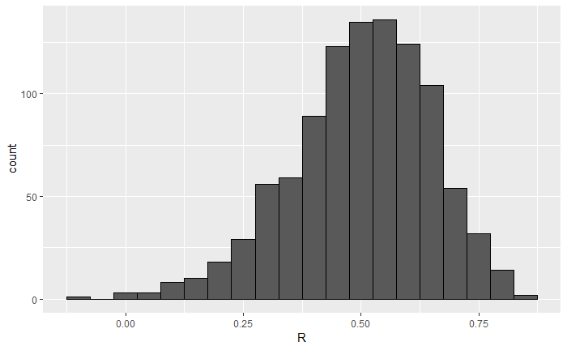

```r
B <- 1000
R <- replicate(B, {
  sample_n(galton_heights, 25, replace = T) %>%
  summarise(r = cor(father, son))%>%
    .$r
})
data.frame(R)%>%
  ggplot(aes(R))+geom_histogram(binwidth = 0.05, color = "black")
```

The correlation can also be applied with the Central Limit Theorem, therefore the correlation coefficient can be model by a normal variable with parameters:

$R \sim N(\rho,\sqrt(\frac{1-r^2}{N-2})$

Correlation is not always a good solution to infer trend between variables - One example is the Ascombe quartet, a conjunct of artificial data with different trends, in which all of them produce the same correlation coefficient

## Stratification

One way to predict son height based on the sample information and the father’s height is to do a stratification of the population and compute the conditional average:

```r
conditional_average <- galton_heights %>%
  filter(round(father)==72)%>%
  summarise(avg = mean(son))%>%
  .$avg
conditional_average
```

[output not shown]

This is larger than the average son.

stratification by boxplot can help to identify these stratas:

```r
galton_heights%>%
  mutate(father_strata = factor(round(father)))%>%
  ggplot(aes(x = father_strata,y = son))+
  geom_boxplot()+
  geom_point()
```

[output not shown]

The means of each group seem to have a linear relationship:

```r
galton_heights%>%
  mutate(father_strata = factor(round(father)))%>%
  select(father_strata, son)%>%
  group_by(father_strata)%>%
  summarise(mean = mean(son))%>%
  mutate(father_strata = as.numeric(father_strata))%>%
  ggplot(aes(scale(father_strata), scale(mean)))+
  geom_point()+geom_abline(intercept = 0, slope = 0.5)
```

[output not shown]

## Bivariate Normal Distribution

When a pair or variables (x,y) appear in a scatterplot with oval shape, it can be modelled as a bivariate normal distriution. Two variables highly correlated have a thin shape, or a circle if no correlation exists. both x and y must be approximately normally distributed.

```r
sd <- galton_heights %>%
  summarise(sd = sd(son))%>%
  pull(sd)
1-(1-0.5^2)*sd^2/sd^2
```

[output not shown]

## Basics of Evaluating Machine Learning Algorithms

```r
ncol(mnist$train$images)
```

```
[1] 784
```

So there are 784 features to evaluate each letter

```r
y[5]>y[6]
```

```
[1] TRUE
```

## Comprehension Check: Confusion Matrix

```r
library(dslabs)
library(dplyr)
library(lubridate)
data("reported_heights")
dat <- mutate(reported_heights, date_time = ymd_hms(time_stamp)) %>%
  filter(date_time >= make_date(2016, 01, 25) & date_time < make_date(2016, 02, 1)) %>%
  mutate(type = ifelse(day(date_time) == 25 & hour(date_time) == 8 & between(minute(date_time), 15, 30), "inclass","online")) %>%
  select(sex, type)
y <- factor(dat$sex, c("Female", "Male"))
x <- dat$type
```

[output not shown]

Accuracy of Guessing:

```r
dat %>%
  group_by(type)%>%
  summarise(n = n())%>%
  mutate(n = n/sum(n))
```

| type | n |
| --- | --- |
| inclass | 0.26 |
| online | 0.74 |

```r
0.74*0.6216216  + 0.26*0.6666667
```

```
[1] 0.6333333
```

```r
y_hat <- ifelse(x == "inclass", "Female", "Male")
y_hat <- factor(y_hat, c("Female", "Male"))
confM <- table(predicted = y_hat, actual = y)
confM
#Sensitivity
confM[1,1]/(confM[1,1]+confM[2,1])
#Specificity
confM[2,2]/(confM[1,2]+confM[2,2])
#prevalence
mean(dat$sex["Female"])
```

[output not shown]